# confounders

### PERMANOVA test

```r
permanova <- function(physeq, factorName, ifnumeric, pmt = 999){
  set.seed(1)
  braydist = phyloseq::distance(physeq, "bray")
  form <- as.formula(paste("braydist ~ ", c(factorName), sep = ""))
  metaDF=data.frame(sample_data(physeq)[, c(as.character(factorName), "Within.study.sampling.date")])
  # if numerical variable, make sure the class
  if(ifnumeric){
    metaDF[, factorName] <- as.numeric(metaDF[, factorName])
    factor_class='numeric'
  } else {
    factor_class='categorical'
  }
  perm <- adonis(form, strata = metaDF$Within.study.sampling.date, permutations = pmt, metaDF)
  permDT=data.table(Variable=factorName,
             FactorClass=factor_class,
             TotalN=perm$aov.tab['Total','Df']+1,
             R2=perm$aov.tab[factorName, 'R2'],
             pvalue=perm$aov.tab[factorName,'Pr(>F)'][1])
  return(permDT)
}
#we keep only the cateory selected above as relevant
tmp_metadata <- map[,c(num_cat,fac_cat)]
#For categorical variables, keep only those with 2 or more possible answers
cat_drop <- sapply(tmp_metadata[ , fac_cat], function(x) return(length(levels(x)) < 2))
fac_cat_drop <- fac_cat[cat_drop]
tmp_metadata <- tmp_metadata[, -which(colnames(tmp_metadata) %in% fac_cat_drop)]
#For all variables, keep only those where at least 20% have valid answers
cols_keep <- as.vector(apply(tmp_metadata, 2, function(x) return(sum(is.na(x)) < length(x)*.8 )))
metadata <- tmp_metadata[ , cols_keep]
# filter out variables with n-4 all same responses across datset (140 out of 144 samples (at least 420 same responses))
cols_keep <- as.vector(apply(metadata, 2, function(x) return(sum(table(x)[which(table(x) >= 420)] >= 420)))) == 0
metadata <- metadata[ , cols_keep]


#scores for social, learning, and anxiety
social <- c("Language.ability.and.use", "Conversation.ability", "Plays.imaginatively.when.alone", "Plays.imaginatively.with.others", "Plays.in.a.group.with.others", "Eye.contact.finding", "Picks.up.objects.to.show.to.others", "Imitation.behavior")

learning <- c("Understands.speech", "Childhood.behavioral.development.finding")

anxiety <- c("Repetitive.motion", "Sleep.pattern.finding", "Response.to.typical.sounds", "Self.injurious.behavior.finding", "Recent.anxiety..caretaker.reported.")

#MARa variables
cols_away <- c(anxiety[-which(anxiety %in% "Recent.anxiety..caretaker.reported.")], learning, social, "Mobile.Autism.Risk.Assessment.Score")
metadata <- metadata[ , -which(colnames(metadata) %in% cols_away)]


#Test the homogeneity of dispersion before running permanova - we only wish to test variables that are dispersed homogeneously with respect
#to the distances between samples in microbiome space
set.seed(1)
pval_factors_disper=c()
nb_samples_disper=c()
for (i in 1:ncol(metadata)){
  cat (i,"\t")
  #Drop samples that have NA for the specified variable
  test_map <- metadata[!is.na(metadata[,i]) & metadata[,i] != "" ,]
  ps_tmp <- ps_deseq
  sample_data(ps_tmp) <- test_map
  dist_bray <- phyloseq::distance(ps_tmp, method = "bray")
  beta <- betadisper(dist_bray, get_variable(ps_tmp)[, i])
  tmp <- permutest(beta)
  tmp <- tmp$tab$`Pr(>F)`[1]
  pval_factors_disper <- c(pval_factors_disper,tmp)
  nb_samples_disper <- c(nb_samples_disper, nsamples(ps_tmp))}
```

1 2 3 4 5 6 7 8 9 10 11 12 13 14 15 16 17 18 19 20 21 22 23 24 25 26 27 28 29 30 31 32 33 34 35 36 37 38 39 40 41 42 43 44 45 46 47 48 49 50 51 52 53 54 55 56 57 58 59 60 61 62 63 64 65 66 67 68 69 70 71 72 73 74 75 76 77 78 79 80 81 82 83 84

```r
#correct the p.value
names(pval_factors_disper) <- colnames(metadata)
pval_factors_disper <- p.adjust(pval_factors_disper, method = "fdr")
to_remove_betadis <- names(pval_factors_disper)[pval_factors_disper < 0.05]
permanova_df <- metadata[,-which(colnames(metadata) %in% to_remove_betadis)]
set.seed(1)
permanova_res=NULL
for(var_name in colnames(permanova_df)){
  print(var_name)
  #Drop samples that have NA for the specified variable
  test_map <- permanova_df[!is.na(permanova_df[ , var_name]) & permanova_df[ , var_name] != "" , ]
  ps_tmp <- ps_deseq
  sample_data(ps_tmp) <- test_map

  # Check if there is more than 1 values (categories)
  if(uniqueN(ps_tmp@sam_data[ , var_name]) > 1){

    # if categorical
    if(is.factor(permanova_df[[var_name]])){
      # run permanova only if there are more than 1 groups
      p <- permanova(ps_tmp, factorName = var_name, ifnumeric = FALSE, pmt = 999)
      permanova_res=rbindlist(list(permanova_res, p))
      rm(p)
    }
    # if continuous
    if(is.numeric(permanova_df[[var_name]])){
      p <- permanova(ps_tmp, factorName = var_name, ifnumeric = TRUE, pmt = 999)
      permanova_res=rbindlist(list(permanova_res, p))
      rm(p)
    }
  }
  rm(var_name)
}
```

[1] “Fermented.vegetable..consumption.frequency.” [1] “Fruit..consumption.frequency.” [1] “Seafood..consumption.frequency.” [1] “Sugary.food..consumption.frequency.” [1] “Recent.anxiety..caretaker.reported.” [1] “Dairy..consumption.frequency…longitudinal.” [1] “Vegetable..consumption.frequency…longitudinal.” [1] “Within.study.sampling.date” [1] “Pets.in.home” [1] “Outdoors.pet” [1] “Other.GI.symptoms..M3.” [1] “GI.symptoms.within.3.months..M3.” [1] “GI.issues.this.week..M3.” [1] “GI.issues.two.weeks.ago..M3.” [1] “Non.celiac.gluten.sensitivity” [1] “Lactose.intolerance” [1] “Multivitamin” [1] “Dietary.restrictions..M3.” [1] “Dietary.supplement” [1] “Problems.collecting.stool.sample..M3.” [1] “Toilet.trained” [1] “Recently.ill” [1] “Flu.like.symptoms” [1] “phenotype” [1] “High_Anxiety”

```r
#Correct p_value with fdr (added Oct_14_2020)
permanova_res$pvalue_adj<-  p.adjust(permanova_res$pvalue, method = "fdr")

#permanova_res <- permanova_res[!(permanova_res$Variable %in% c("Language.ability.and.use", "Conversation.ability", #"Plays.imaginatively.when.alone", "Plays.imaginatively.with.others", "Plays.in.a.group.with.others", #"Eye.contact.finding", "Picks.up.objects.to.show.to.others", "Imitation.behavior","Understands.speech", #"Childhood.behavioral.development.finding","Repetitive.motion", "Sleep.pattern.finding", "Response.to.typical.sounds", #"Self.injurious.behavior.finding", "Gastrointestinal.problems..M3.")),]
# sort
permanova_res <- permanova_res[order(permanova_res$R2, decreasing=TRUE), ]
permanova_res$R2 <- round(permanova_res$R2, digits = 3)
permanova_res$pvalue_adj <- round(permanova_res$pvalue_adj, digits = 3)
datatable(permanova_res)
```

|  | Variable | FactorClass | TotalN | R2 | pvalue | pvalue_adj |
| --- | --- | --- | --- | --- | --- | --- |
| 1 | Vegetable..consumption.frequency...longitudinal. | numeric | 405 | 0.027 | 0.001 | 0.002 |
| 2 | Fruit..consumption.frequency. | numeric | 432 | 0.012 | 0.001 | 0.002 |
| 3 | Outdoors.pet | categorical | 366 | 0.011 | 0.001 | 0.002 |
| 4 | Non.celiac.gluten.sensitivity | categorical | 432 | 0.011 | 0.001 | 0.002 |
| 5 | Other.GI.symptoms..M3. | categorical | 366 | 0.01 | 0.001 | 0.002 |
| 6 | Sugary.food..consumption.frequency. | numeric | 432 | 0.01 | 0.001 | 0.002 |
| 7 | Pets.in.home | categorical | 432 | 0.009 | 0.001 | 0.002 |
| 8 | Dairy..consumption.frequency...longitudinal. | numeric | 405 | 0.009 | 0.001 | 0.002 |
| 9 | Toilet.trained | categorical | 405 | 0.008 | 0.001 | 0.002 |
| 10 | Lactose.intolerance | categorical | 432 | 0.008 | 0.001 | 0.002 |

[output cut: 15 more lines]

```r
write.csv(permanova_res, file=paste0(output_data, 'PERMANOVA_noLR.csv'), row.names=FALSE)
```

## Visualize permanova significant variables on PCoA

```r
# function to plot PCoA, only for higher R2 value
#permanova_res <- permanova_res[permanova_res$pvalue_adj < 0.05,]

imp_factors<-permanova_res$Variable#[permanova_res$R2 > 0.009]
imp_factors <- gsub(".1","", imp_factors)

#Drop factors that have too many NA values
keep_factors <- imp_factors[apply(map[, imp_factors], 2 ,function(x) return(sum(is.na(x)) < 30))]
#Drop samples that have NA for any of the factors of interest
map_plot <- map[ , keep_factors]
map_plot <- map_plot[complete.cases(map_plot), ]

ps_deseq_pcoa <- ps_deseq
sample_data(ps_deseq_pcoa) <- map_plot
f <- as.formula(paste0("~", paste0(colnames(map_plot), collapse = "+")))

#ordination formula .
ord_pcoa <- ordinate(
  physeq = ps_deseq_pcoa,
  method = "CAP",
  distance = "bray",
  formula = f)

title_prep <- c(colnames(map_plot), "phenotype", "Annual.household.income_rank")
to_plot=list()
for (i in 1:length(title_prep)){
  to_plot[[i]] <- plot_ordination(
  physeq = ps_deseq,
  ordination = ord_pcoa,
  color = title_prep[i],
  axes = c(1,2),
  title=title_prep[i]
) +
 geom_point( size = 0.15) +
 theme(text = element_text(size =7.5), plot.title = element_text(size=10), legend.title = element_blank())
}
to_plot[[length(title_prep)+1]] <- plot_ordination(physeq = ps_deseq, ordination = ord_pcoa, type="taxa",title ="Taxa") + theme(text = element_text(size =5), legend.title = element_blank())

pdf(paste0(output_data,"confounding_factors.pdf"))
#grid.arrange(grobs = as.list(to_plot), layout_matrix = lay)
plot_grid(plotlist = to_plot[c(1:3)], ncol = 2)
#plot_grid(plotlist = to_plot[c(5:8)], ncol = 2)
#plot_grid(plotlist = to_plot[c(9:12)], ncol = 2)
#plot_grid(plotlist = to_plot[c(13:16)], ncol = 2)
#plot_grid(plotlist = to_plot[c(17:20)], ncol = 2)
#plot_grid(plotlist = to_plot[c(21:24)], ncol = 2)
#plot_grid(plotlist = to_plot[c(25:28)], ncol = 2)
#plot_grid(plotlist = to_plot[c(29:31)], ncol = 2)
dev.off()
```

```r
top_potential_confounds <- keep_factors
top_potential_confounds
```

```
##  [1] "Vegetable..consumption.frequency...longitudinal."
##  [2] "Fruit..consumption.frequency."
##  [3] "Non.celiac.gluten.sensitivity"
##  [4] "Sugary.food..consumption.frequency."
##  [5] "Pets.in.home"
##  [6] "Dairy..consumption.frequency...longitudinal."
##  [7] "Toilet.trained"
##  [8] "Lactose.intolerance"
##  [9] "Dietary.restrictions..M3."
## [10] "Seafood..consumption.frequency."
## [11] "Multivitamin"
## [12] "Fermented.vegetable..consumption.frequency."
## [13] "GI.symptoms.within.3.months..M3."
## [14] "GI.issues.this.week..M3."
## [15] "Recently.ill"
## [16] "GI.issues.two.weeks.ago..M3."
## [17] "Recent.anxiety..caretaker.reported."
## [18] "phenotype"
## [19] "Problems.collecting.stool.sample..M3."
## [20] "High_Anxiety"
## [21] "Flu.like.symptoms"
## [22] "Within.study.sampling.date"
```

## With these variables added into ordination

```r
i = "phenotype"
f <- as.formula(paste0("~", paste0(colnames(map_plot), collapse = "+"),"+", i))

#Drop samples that have NA for any of the factors of interest
map_plot <- map[ , c(keep_factors, "phenotype", "Annual.household.income_rank")]
map_plot <- map_plot[complete.cases(map_plot), ]

ps_deseq_pcoa <- ps_deseq
sample_data(ps_deseq_pcoa) <- map_plot

#ordination formula
ps_deseq_pcoa
```

```
## phyloseq-class experiment-level object
## otu_table()   OTU Table:         [ 834 taxa and 372 samples ]
## sample_data() Sample Data:       [ 372 samples by 24 sample variables ]
## tax_table()   Taxonomy Table:    [ 834 taxa by 8 taxonomic ranks ]
```

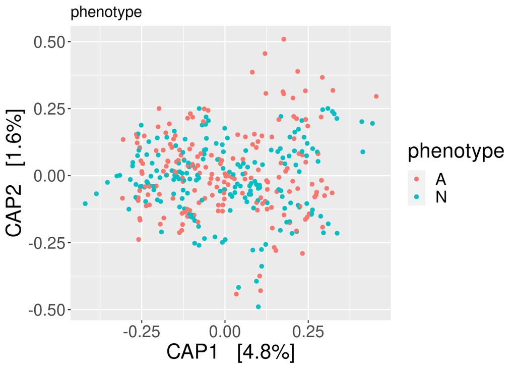

```r
ord_pcoa <- ordinate(
  physeq = ps_deseq_pcoa,
  method = "CAP",
  distance = "bray",
  formula = f)
plot_ordination(
  physeq = ps_deseq,
  ordination = ord_pcoa,
  color = i,
  axes = c(1,2),
  title=i
) +
  geom_point( size = 0.5) +
  theme(text = element_text(size =20), plot.title = element_text(size=15))
```

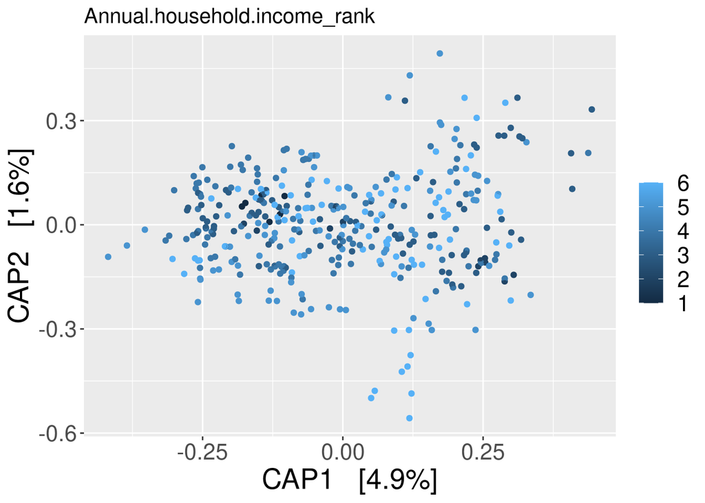

```r
i = "Annual.household.income_rank"
f <- as.formula(paste0("~", paste0(colnames(map_plot), collapse = "+"), "+", i))
ord_pcoa <- ordinate(
  physeq = ps_deseq_pcoa,
  method = "CAP",
  distance = "bray",
  formula = f)
plot_ordination(
  physeq = ps_deseq,
  ordination = ord_pcoa,
  color = i,
  axes = c(1,2),
  title=i
) +
  geom_point( size = 0.5) +
  theme(text = element_text(size =20), plot.title = element_text(size=15), legend.title = element_blank())
```

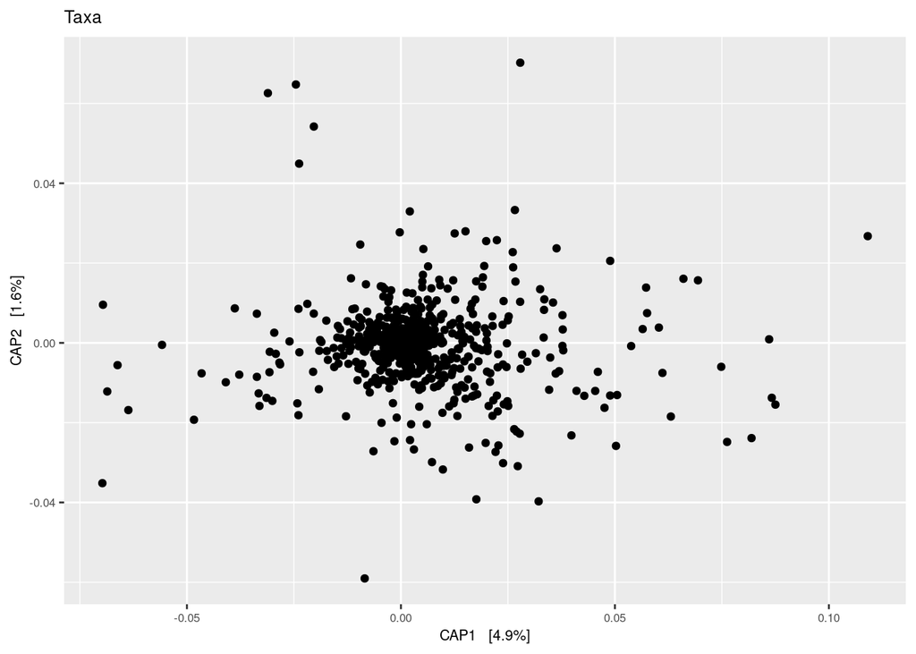

```r
#Let's have a look at the plot
plot_ordination(physeq = ps_deseq, ordination = ord_pcoa, type="taxa",title ="Taxa") + theme(text = element_text(size =8))
```

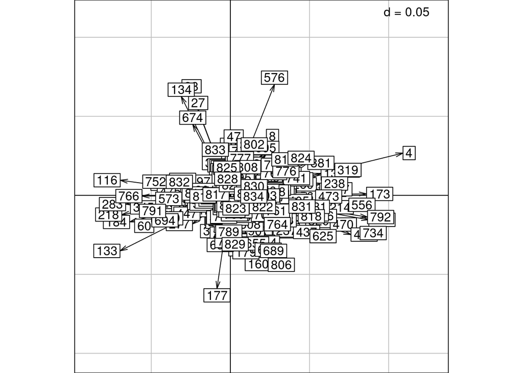

```r
#ok let's try to find the spcies that show some importance in this PCA
taxa.to.select<-vegan::scores(ord_pcoa)$species
#now plot it with no name for visibilty
rownames(taxa.to.select)<-c()
s.arrow(taxa.to.select) #the taxa that influence the most the plots are above 0.1
```

```r
scores = vegan::scores(ord_pcoa)$species
taxa.to.select.to.rem <- scores[as.vector(abs(scores[,1])>0.1 | abs(scores[,2])>0.1),]

#any overlap with the 5 important?
deseq_res <- readRDS(paste0(output_data, "DESeq/full_res_table_deseq.rds"))
rownames(deseq_res) %in% taxa.to.select.to.rem #NOPE!
```

```
##  [1] FALSE FALSE FALSE FALSE FALSE FALSE FALSE FALSE FALSE FALSE FALSE FALSE
```

```r
saveRDS(taxa.to.select.to.rem, paste0(output_data, "taxa_associated_confounding_variables.rds"))
```

## MARA ordinated variables only in ASD cohort

```r
permanova <- function(physeq, factorName, ifnumeric, pmt = 999){
  set.seed(1)
  braydist = phyloseq::distance(physeq, "bray")
  form <- as.formula(paste("braydist ~ ", c(factorName), sep = ""))
  metaDF=data.frame(sample_data(physeq)[, as.character(factorName)])
  # if numerical variable, make sure the class
  if(ifnumeric){
    metaDF[, factorName] <- as.numeric(metaDF[, factorName])
    factor_class='numeric'
  } else {
    factor_class='categorical'
  }
  perm <- adonis(form, permutations = pmt, metaDF)
  permDT=data.table(Variable=factorName,
             FactorClass=factor_class,
             TotalN=perm$aov.tab['Total','Df']+1,
             R2=perm$aov.tab[factorName, 'R2'],
             pvalue=perm$aov.tab[factorName,'Pr(>F)'][1])
  return(permDT)
}

#we keep only the cateory selected above as relevant
tmp_metadata <- map[,c(num_cat,fac_cat)]

#scores for social, learning, and anxiety
social <- c("Language.ability.and.use", "Conversation.ability", "Plays.imaginatively.when.alone", "Plays.imaginatively.with.others", "Plays.in.a.group.with.others", "Eye.contact.finding", "Picks.up.objects.to.show.to.others", "Imitation.behavior")

learning <- c("Understands.speech", "Childhood.behavioral.development.finding")

anxiety <- c("Repetitive.motion", "Sleep.pattern.finding", "Response.to.typical.sounds", "Self.injurious.behavior.finding", "Recent.anxiety..caretaker.reported.")

#only ASD
tmp_metadata<-tmp_metadata[tmp_metadata$phenotype == "A",]
ps_deseq_ASD <-subset_samples(ps_deseq, phenotype == "A")

#MARa variables
cols_keep <- c(anxiety[-which(anxiety %in% "Recent.anxiety..caretaker.reported.")], learning, social)
metadata <- tmp_metadata[ , c(cols_keep, "Mobile.Autism.Risk.Assessment.Score")]



#Test the homogeneity of dispersion before running permanova - we only wish to test variables that are dispersed homogeneously with respect
#to the distances between samples in microbiome space
run_behavior_perma_per_time<-function(t){
set.seed(1)
pval_factors_disper=c()
nb_samples_disper=c()
keep <- ps_deseq_ASD@sam_data$Within.study.sampling.date == t
ps <- prune_samples(keep, ps_deseq_ASD)
for (i in 1:ncol(metadata)){
  cat (i,"\t")
  #Drop samples that have NA for the specified variable
  test_map <- metadata[!is.na(metadata[,i]) & metadata[,i] != "" ,]
  ps_tmp <- ps
  sample_data(ps_tmp) <- test_map

  dist_bray <- phyloseq::distance(ps_tmp, method = "bray")
  beta <- betadisper(dist_bray, get_variable(ps_tmp)[, i])
  tmp <- permutest(beta)
  tmp <- tmp$tab$`Pr(>F)`[1]
  pval_factors_disper <- c(pval_factors_disper,tmp)
  nb_samples_disper <- c(nb_samples_disper, nsamples(ps_tmp))}

#correct the p.value
names(pval_factors_disper) <- colnames(metadata)
pval_factors_disper <- p.adjust(pval_factors_disper, method = "fdr")
to_remove_betadis <- names(pval_factors_disper)[pval_factors_disper < 0.05]

permanova_df <- metadata[,-which(colnames(metadata) %in% to_remove_betadis)]
set.seed(1)
permanova_res=NULL
for(var_name in colnames(permanova_df)){
  print(var_name)
  #Drop samples that have NA for the specified variable
  test_map <- permanova_df[!is.na(permanova_df[ , var_name]) & permanova_df[ , var_name] != "" , ]
  ps_tmp <- ps
  sample_data(ps_tmp) <- test_map

  # Check if there is more than 1 values (categories)
  if(uniqueN(ps_tmp@sam_data[ , var_name]) > 1){

    # if categorical
    if(is.factor(permanova_df[[var_name]])){
      # run permanova only if there are more than 1 groups
      p <- permanova(ps_tmp, factorName = var_name, ifnumeric = FALSE, pmt = 999)
      permanova_res=rbindlist(list(permanova_res, p))
      rm(p)
    }
    # if continuous
    if(is.numeric(permanova_df[[var_name]])){
      p <- permanova(ps_tmp, factorName = var_name, ifnumeric = TRUE, pmt = 999)
      permanova_res=rbindlist(list(permanova_res, p))
      rm(p)
    }
  }
  rm(var_name)
}

#Correct p_value with fdr (added Oct_14_2020)
permanova_res$pvalue_adj<-  p.adjust(permanova_res$pvalue, method = "fdr")


# sort
permanova_res <- permanova_res[order(permanova_res$R2, decreasing=TRUE), ]
return(permanova_res)
#permanova_res$R2 <- round(permanova_res$R2, digits = 3)
#permanova_res$pvalue_adj <- round(permanova_res$pvalue_adj, digits = 3)
}

behav_res1<-run_behavior_perma_per_time("Timepoint 1")
```

```
## 1    2   3   4   5   6   7   8   9   10  11  12  13  14  15  [1] "Repetitive.motion"
## [1] "Sleep.pattern.finding"
## [1] "Response.to.typical.sounds"
## [1] "Self.injurious.behavior.finding"
## [1] "Understands.speech"
## [1] "Childhood.behavioral.development.finding"
## [1] "Language.ability.and.use"
## [1] "Conversation.ability"
## [1] "Plays.imaginatively.when.alone"
## [1] "Plays.imaginatively.with.others"
## [1] "Plays.in.a.group.with.others"
## [1] "Eye.contact.finding"
## [1] "Picks.up.objects.to.show.to.others"
## [1] "Imitation.behavior"
```

```r
behav_res2<-run_behavior_perma_per_time("Timepoint 2")
```

```
## 1    2   3   4   5   6   7   8   9   10  11  12  13  14  15  [1] "Repetitive.motion"
## [1] "Sleep.pattern.finding"
## [1] "Response.to.typical.sounds"
## [1] "Self.injurious.behavior.finding"
## [1] "Understands.speech"
## [1] "Childhood.behavioral.development.finding"
## [1] "Language.ability.and.use"
## [1] "Conversation.ability"
## [1] "Plays.imaginatively.when.alone"
## [1] "Plays.imaginatively.with.others"
## [1] "Plays.in.a.group.with.others"
## [1] "Eye.contact.finding"
## [1] "Picks.up.objects.to.show.to.others"
## [1] "Imitation.behavior"
```

```r
behav_res3<-run_behavior_perma_per_time("Timepoint 3")
```

```
## 1    2   3   4   5   6   7   8   9   10  11  12  13  14  15  [1] "Repetitive.motion"
## [1] "Sleep.pattern.finding"
## [1] "Response.to.typical.sounds"
## [1] "Understands.speech"
## [1] "Childhood.behavioral.development.finding"
## [1] "Language.ability.and.use"
## [1] "Conversation.ability"
## [1] "Plays.imaginatively.when.alone"
## [1] "Plays.imaginatively.with.others"
## [1] "Plays.in.a.group.with.others"
## [1] "Eye.contact.finding"
## [1] "Picks.up.objects.to.show.to.others"
## [1] "Imitation.behavior"
```

```r
#No sig
behav_all_res<-rbind(behav_res1[which(behav_res1$pvalue_adj< 0.05),], behav_res2[which(behav_res2$pvalue_adj< 0.05),], behav_res3[which(behav_res3$pvalue_adj< 0.05),])

behav_all_res
```

```
## Empty data.table (0 rows and 6 cols): Variable,FactorClass,TotalN,R2,pvalue,pvalue_adj
```

```r
behav_nonsig_table <- rbind(behav_res1, behav_res2, behav_res3)

#freq<-freq_table(behav_all_res$Variable)

#behav_all_res<-behav_all_res[which(behav_all_res$Variable %in% freq$group[which(freq$n == 3)]),]

#permanova_res <- NULL
#for(i in unique(behav_all_res$Variable)){
#  tmp<-behav_all_res[which(behav_all_res$Variable == i),]
#  tmptable<-tibble(unique(tmp$Variable), unique(tmp$FactorClass), sum(tmp$TotalN), mean(tmp$R2), sd(tmp$R2))
#  colnames(tmptable) <- c("Variable", "FactorClass", "TotalN", "Mean R2", "Std. Dev")
#  tmptable$`Mean R2` <- round(tmptable$`Mean R2`, digits = 3)
#  tmptable$`Std. Dev` <- round(tmptable$`Std. Dev`, digits = 3)
#  permanova_res<-rbind(permanova_res, tmptable)
#}

datatable(behav_nonsig_table)
```

|  | Variable | FactorClass | TotalN | R2 | pvalue | pvalue_adj |
| --- | --- | --- | --- | --- | --- | --- |
| 1 | Plays.imaginatively.with.others | numeric | 71 | 0.0191061734372501 | 0.108 | 0.896 |
| 2 | Childhood.behavioral.development.finding | numeric | 63 | 0.0174283275021556 | 0.285 | 0.896 |
| 3 | Plays.imaginatively.when.alone | numeric | 72 | 0.0161177772151985 | 0.195 | 0.896 |
| 4 | Conversation.ability | numeric | 72 | 0.0149969330517912 | 0.313 | 0.896 |
| 5 | Eye.contact.finding | numeric | 72 | 0.0141222090502177 | 0.413 | 0.896 |
| 6 | Plays.in.a.group.with.others | numeric | 72 | 0.0140537637644214 | 0.397 | 0.896 |
| 7 | Language.ability.and.use | numeric | 72 | 0.0133987862987787 | 0.503 | 0.896 |
| 8 | Understands.speech | numeric | 72 | 0.013278212774088 | 0.523 | 0.896 |
| 9 | Response.to.typical.sounds | numeric | 72 | 0.0118639958091813 | 0.719 | 0.896 |
| 10 | Self.injurious.behavior.finding | numeric | 72 | 0.0115191494074916 | 0.761 | 0.896 |

[output cut: 31 more lines]

```r
write.csv(behav_nonsig_table, file ="../results/MARA_var_perma.csv")

#common
#total <- read.csv('../results/PERMANOVA_noLR.csv')
#permanova_res$Variable %in% total$Variable
```

## Method 2 strata for behavior

```r
permanova <- function(physeq, factorName, ifnumeric, pmt = 999){
  set.seed(1)
  braydist = phyloseq::distance(physeq, "bray")
  form <- as.formula(paste("braydist ~ ", c(factorName), sep = ""))
  metaDF=data.frame(sample_data(physeq)[, c(as.character(factorName), "Within.study.sampling.date")])
  # if numerical variable, make sure the class
  if(ifnumeric){
    metaDF[, factorName] <- as.numeric(metaDF[, factorName])
    factor_class='numeric'
  } else {
    factor_class='categorical'
  }
  perm <- adonis(form, strata = metaDF$Within.study.sampling.date, permutations = pmt, metaDF)
  permDT=data.table(Variable=factorName,
             FactorClass=factor_class,
             TotalN=perm$aov.tab['Total','Df']+1,
             R2=perm$aov.tab[factorName, 'R2'],
             pvalue=perm$aov.tab[factorName,'Pr(>F)'][1])
  return(permDT)
}

#we keep only the cateory selected above as relevant
tmp_metadata <- map[,c(num_cat,fac_cat)]

#scores for social, learning, and anxiety
social <- c("Language.ability.and.use", "Conversation.ability", "Plays.imaginatively.when.alone", "Plays.imaginatively.with.others", "Plays.in.a.group.with.others", "Eye.contact.finding", "Picks.up.objects.to.show.to.others", "Imitation.behavior")

learning <- c("Understands.speech", "Childhood.behavioral.development.finding")

anxiety <- c("Repetitive.motion", "Sleep.pattern.finding", "Response.to.typical.sounds", "Self.injurious.behavior.finding", "Recent.anxiety..caretaker.reported.")

#only ASD
tmp_metadata<-tmp_metadata[tmp_metadata$phenotype == "A",]
ps_deseq_ASD <-subset_samples(ps_deseq, phenotype == "A")

#MARa variables
cols_keep <- c(anxiety[-which(anxiety %in% "Recent.anxiety..caretaker.reported.")], learning, social)
metadata <- tmp_metadata[ , c(cols_keep, "Mobile.Autism.Risk.Assessment.Score", "Within.study.sampling.date")]



#Test the homogeneity of dispersion before running permanova - we only wish to test variables that are dispersed homogeneously with respect
#to the distances between samples in microbiome space
set.seed(1)
pval_factors_disper=c()
nb_samples_disper=c()

ps <- ps_deseq_ASD
for (i in 1:ncol(metadata)){
  cat (i,"\t")
  #Drop samples that have NA for the specified variable
  test_map <- metadata[!is.na(metadata[,i]) & metadata[,i] != "" ,]
  ps_tmp <- ps
  sample_data(ps_tmp) <- test_map

  dist_bray <- phyloseq::distance(ps_tmp, method = "bray")
  beta <- betadisper(dist_bray, get_variable(ps_tmp)[, i])
  tmp <- permutest(beta)
  tmp <- tmp$tab$`Pr(>F)`[1]
  pval_factors_disper <- c(pval_factors_disper,tmp)
  nb_samples_disper <- c(nb_samples_disper, nsamples(ps_tmp))}
```

```
## 1    2   3   4   5   6   7   8   9   10  11  12  13  14  15
```

```
## 16
```

```r
#correct the p.value
names(pval_factors_disper) <- colnames(metadata)
pval_factors_disper <- p.adjust(pval_factors_disper, method = "fdr")
to_remove_betadis <- names(pval_factors_disper)[pval_factors_disper < 0.05]

permanova_df <- metadata[,-which(colnames(metadata) %in% to_remove_betadis)]
set.seed(1)
permanova_res=NULL
for(var_name in colnames(permanova_df)){
  print(var_name)
  #Drop samples that have NA for the specified variable
  test_map <- permanova_df[!is.na(permanova_df[ , var_name]) & permanova_df[ , var_name] != "" , ]
  ps_tmp <- ps
  sample_data(ps_tmp) <- test_map

  # Check if there is more than 1 values (categories)
  if(uniqueN(ps_tmp@sam_data[ , var_name]) > 1){

    # if categorical
    if(is.factor(permanova_df[[var_name]])){
      # run permanova only if there are more than 1 groups
      p <- permanova(ps_tmp, factorName = var_name, ifnumeric = FALSE, pmt = 999)
      permanova_res=rbindlist(list(permanova_res, p))
      rm(p)
    }
    # if continuous
    if(is.numeric(permanova_df[[var_name]])){
      p <- permanova(ps_tmp, factorName = var_name, ifnumeric = TRUE, pmt = 999)
      permanova_res=rbindlist(list(permanova_res, p))
      rm(p)
    }
  }
  rm(var_name)
}
```

```
## [1] "Repetitive.motion"
## [1] "Sleep.pattern.finding"
## [1] "Response.to.typical.sounds"
## [1] "Childhood.behavioral.development.finding"
## [1] "Language.ability.and.use"
## [1] "Plays.imaginatively.with.others"
## [1] "Plays.in.a.group.with.others"
## [1] "Eye.contact.finding"
## [1] "Picks.up.objects.to.show.to.others"
## [1] "Imitation.behavior"
## [1] "Within.study.sampling.date"
```

```r
#Correct p_value with fdr (added Oct_14_2020)
permanova_res$pvalue_adj<-  p.adjust(permanova_res$pvalue, method = "fdr")


# sort
permanova_res <- permanova_res[order(permanova_res$R2, decreasing=TRUE), ]
#return(permanova_res)
permanova_res$R2 <- round(permanova_res$R2, digits = 3)
permanova_res$pvalue_adj <- round(permanova_res$pvalue_adj, digits = 3)
behav_all_res <- permanova_res

#10sig
behav_all_res<-behav_all_res[which(behav_all_res$pvalue_adj< 0.05),]

datatable(behav_all_res)
```

|  | Variable | FactorClass | TotalN | R2 | pvalue | pvalue_adj |
| --- | --- | --- | --- | --- | --- | --- |
| 1 | Childhood.behavioral.development.finding | numeric | 189 | 0.016 | 0.001 | 0.004 |
| 2 | Plays.imaginatively.with.others | numeric | 213 | 0.015 | 0.001 | 0.004 |
| 3 | Language.ability.and.use | numeric | 216 | 0.011 | 0.001 | 0.004 |
| 4 | Plays.in.a.group.with.others | numeric | 216 | 0.011 | 0.006 | 0.011 |
| 5 | Sleep.pattern.finding | numeric | 216 | 0.01 | 0.004 | 0.009 |
| 6 | Eye.contact.finding | numeric | 216 | 0.01 | 0.002 | 0.006 |
| 7 | Repetitive.motion | numeric | 216 | 0.009 | 0.01 | 0.016 |
| 8 | Response.to.typical.sounds | numeric | 216 | 0.009 | 0.019 | 0.023 |
| 9 | Picks.up.objects.to.show.to.others | numeric | 216 | 0.008 | 0.019 | 0.023 |
| 10 | Imitation.behavior | numeric | 216 | 0.008 | 0.032 | 0.035 |

```r
write.csv(behav_all_res, file ="../results/MARA_var_perma.csv")

#determine if sig with "perfect" values in TD

tmp_metadata <- map[,c(num_cat,fac_cat)]

tmp_metadata$Repetitive.motion[which(is.na(tmp_metadata$Repetitive.motion))] <- 1
tmp_metadata$Sleep.pattern.finding[which(is.na(tmp_metadata$Sleep.pattern.finding))] <- 1
tmp_metadata$Response.to.typical.sounds[which(is.na(tmp_metadata$Response.to.typical.sounds))] <- 1
tmp_metadata$Self.injurious.behavior.finding[which(is.na(tmp_metadata$Self.injurious.behavior.finding))] <- 1

tmp_metadata$Understands.speech[which(is.na(tmp_metadata$Understands.speech))] <- 4
tmp_metadata$Childhood.behavioral.development.finding[which(is.na(tmp_metadata$Childhood.behavioral.development.finding))] <- 4
tmp_metadata$Language.ability.and.use[which(is.na(tmp_metadata$Language.ability.and.use))] <- 4
tmp_metadata$Conversation.ability[which(is.na(tmp_metadata$Conversation.ability))] <- 4
tmp_metadata$Plays.imaginatively.when.alone[which(is.na(tmp_metadata$Plays.imaginatively.when.alone))] <- 4
tmp_metadata$Plays.imaginatively.with.others[which(is.na(tmp_metadata$Plays.imaginatively.with.others))] <- 4
tmp_metadata$Plays.in.a.group.with.others[which(is.na(tmp_metadata$Plays.in.a.group.with.others))] <- 4
tmp_metadata$Eye.contact.finding[which(is.na(tmp_metadata$Eye.contact.finding))] <- 4
tmp_metadata$Picks.up.objects.to.show.to.others[which(is.na(tmp_metadata$Picks.up.objects.to.show.to.others))] <- 4
tmp_metadata$Imitation.behavior[which(is.na(tmp_metadata$Imitation.behavior))] <- 4
tmp_metadata$Mobile.Autism.Risk.Assessment.Score[which(is.na(tmp_metadata$Mobile.Autism.Risk.Assessment.Score))] <- 3

metadata <- tmp_metadata[ , c(cols_keep, "Mobile.Autism.Risk.Assessment.Score", "Within.study.sampling.date")]

#Test the homogeneity of dispersion before running permanova - we only wish to test variables that are dispersed homogeneously with respect
#to the distances between samples in microbiome space
set.seed(1)
pval_factors_disper=c()
nb_samples_disper=c()

ps <- ps_deseq
for (i in 1:ncol(metadata)){
  cat (i,"\t")
  #Drop samples that have NA for the specified variable
  test_map <- metadata[!is.na(metadata[,i]) & metadata[,i] != "" ,]
  ps_tmp <- ps
  sample_data(ps_tmp) <- test_map

  dist_bray <- phyloseq::distance(ps_tmp, method = "bray")
  beta <- betadisper(dist_bray, get_variable(ps_tmp)[, i])
  tmp <- permutest(beta)
  tmp <- tmp$tab$`Pr(>F)`[1]
  pval_factors_disper <- c(pval_factors_disper,tmp)
  nb_samples_disper <- c(nb_samples_disper, nsamples(ps_tmp))}
```

```
## 1    2   3   4   5   6   7   8   9   10  11  12  13  14  15
```

```
## 16
```

```r
#correct the p.value
names(pval_factors_disper) <- colnames(metadata)
pval_factors_disper <- p.adjust(pval_factors_disper, method = "fdr")
to_remove_betadis <- names(pval_factors_disper)[pval_factors_disper < 0.05]

permanova_df <- metadata[,-which(colnames(metadata) %in% to_remove_betadis)]
set.seed(1)
permanova_res=NULL
for(var_name in colnames(permanova_df)){
  print(var_name)
  #Drop samples that have NA for the specified variable
  test_map <- permanova_df[!is.na(permanova_df[ , var_name]) & permanova_df[ , var_name] != "" , ]
  ps_tmp <- ps
  sample_data(ps_tmp) <- test_map

  # Check if there is more than 1 values (categories)
  if(uniqueN(ps_tmp@sam_data[ , var_name]) > 1){

    # if categorical
    if(is.factor(permanova_df[[var_name]])){
      # run permanova only if there are more than 1 groups
      p <- permanova(ps_tmp, factorName = var_name, ifnumeric = FALSE, pmt = 999)
      permanova_res=rbindlist(list(permanova_res, p))
      rm(p)
    }
    # if continuous
    if(is.numeric(permanova_df[[var_name]])){
      p <- permanova(ps_tmp, factorName = var_name, ifnumeric = TRUE, pmt = 999)
      permanova_res=rbindlist(list(permanova_res, p))
      rm(p)
    }
  }
  rm(var_name)
}
```

```
## [1] "Repetitive.motion"
## [1] "Sleep.pattern.finding"
## [1] "Response.to.typical.sounds"
## [1] "Childhood.behavioral.development.finding"
## [1] "Language.ability.and.use"
## [1] "Plays.imaginatively.with.others"
## [1] "Plays.in.a.group.with.others"
## [1] "Eye.contact.finding"
## [1] "Picks.up.objects.to.show.to.others"
## [1] "Imitation.behavior"
## [1] "Within.study.sampling.date"
```

```r
#Correct p_value with fdr (added Oct_14_2020)
permanova_res$pvalue_adj<-  p.adjust(permanova_res$pvalue, method = "fdr")


# sort
permanova_res <- permanova_res[order(permanova_res$R2, decreasing=TRUE), ]
#return(permanova_res)
permanova_res$R2 <- round(permanova_res$R2, digits = 3)
permanova_res$pvalue_adj <- round(permanova_res$pvalue_adj, digits = 3)
behav_all_res <- permanova_res

behav_all_res<-behav_all_res[which(behav_all_res$pvalue_adj< 0.05),]

datatable(behav_all_res)
```

|  | Variable | FactorClass | TotalN | R2 | pvalue | pvalue_adj |
| --- | --- | --- | --- | --- | --- | --- |
| 1 | Sleep.pattern.finding | numeric | 432 | 0.005 | 0.004 | 0.028 |
| 2 | Language.ability.and.use | numeric | 432 | 0.005 | 0.005 | 0.028 |
| 3 | Plays.imaginatively.with.others | numeric | 432 | 0.004 | 0.015 | 0.049 |
| 4 | Plays.in.a.group.with.others | numeric | 432 | 0.004 | 0.018 | 0.049 |

### Metagenomeseq function for permanova variables

```r
run_metagenom_seq<-function(ps, variable, maxit, mcut, time = F){
  ps <- prune_samples(as.vector(!is.na(ps@sam_data[ , variable])), ps)
  p_metag<-phyloseq_to_metagenomeSeq(ps)
  #filtering at least 4 samples
  p_metag= cumNorm(p_metag, p=0.75)
  normFactor =normFactors(p_metag)
  normFactor =log2(normFactor/median(normFactor) + 1)
  if(time == F){
    form <- as.formula(paste("~", variable, "+ normFactor" ))
    mod = model.matrix(form, data = pData(p_metag))
  }
  if(time == T){
    form <- as.formula(paste("~", variable, " + Within.study.sampling.date + normFactor" ))
    mod = model.matrix(form, data = pData(p_metag))
  }

  settings =zigControl(maxit =maxit, verbose =FALSE)
  fit =fitZig(obj = p_metag, mod = mod, useCSSoffset = FALSE, control = settings)
  #Note: changed fit$taxa to fit@taxa in light of error (probably from newer metagenomeseq ver.)
  res_fit_nonfiltered <- MRtable(fit, number = length(fit@taxa))
  res_fit<-res_fit_nonfiltered[res_fit_nonfiltered$adjPvalues<mcut,]
  #finally remove the ones that are not with enough samples
  Min_effec_samp<-calculateEffectiveSamples(fit)
  Min_effec_samp<-Min_effec_samp[ names(Min_effec_samp)  %in% rownames(res_fit)] #####there is a bug here
  #manually removing the ones with "NA"
  res_fit<-res_fit[grep("NA",rownames(res_fit), inv=T),]
  res_fit$Min_sample<-Min_effec_samp
  res_fit<-res_fit[res_fit$`+samples in group 0` >= Min_effec_samp & res_fit$`+samples in group 1` >= Min_effec_samp,]
  return(list(res_fit_nonfiltered, res_fit))
}
```

## For each significant variable in permanova test, use DESeq and metagenomeseq to identify the taxa relevant to that variable

```r
permanova_res <- read.csv('../results/PERMANOVA_noLR.csv')
permanova_res <- permanova_res[permanova_res$pvalue_adj < 0.05,]
MARA <-read.csv(file ="../results/MARA_var_perma.csv")
behavior <-c(anxiety[-which(anxiety %in% "Recent.anxiety..caretaker.reported.")], learning, social)
take_out<-behavior#[-which(behavior %in% MARA$Variable)]
if(nrow(permanova_res[-which(permanova_res$Variable %in% take_out),]) != 0){
permanova_res<-permanova_res[-which(permanova_res$Variable %in% take_out),]
}
write.csv(permanova_res,"../filtered_perm_res.csv")

ps_no_norm_filt <- readRDS(paste0(output_data, "Filtered/ps_no_norm_friedfilt.rds"))
taxa_associated_w_variables <- list()
perma_var<-permanova_res$Variable

#Will add in age
perma_var <- c(as.character(perma_var), "Age..months.")


for(var in perma_var[1:length(perma_var)]){
  print(var)
  tmp <- run_metagenom_seq(ps_no_norm_filt, variable = as.character(var), 30, .05, time = T)
  print(paste0("taxa=",nrow(tmp[[2]])))
  print(paste0("totalgroup0counts", sum(tmp[[1]]$`+samples in group 0`)))
  print(paste0("totalgroup1counts", sum(tmp[[1]]$`+samples in group 1`)))
  if (nrow(tmp[[2]]) !=0){
  if (is.numeric(get_variable(ps_no_norm_filt, var)) == FALSE){
  taxa_associated_w_variables[[var]] <- data.frame(rownames(tmp[[2]]), tmp[[2]]$adjPvalues, rep(var, nrow(tmp[[2]])), tmp[[2]][, paste0(var, "TRUE")] >= 0)
  colnames(taxa_associated_w_variables[[var]]) <- c("ASV", "adjPvalue", "variable", "enrichment")} else{
  taxa_associated_w_variables[[var]] <- data.frame(rownames(tmp[[2]]), tmp[[2]]$adjPvalues, rep(var, nrow(tmp[[2]])), tmp[[2]][, var] >= 0)
  colnames(taxa_associated_w_variables[[var]]) <- c("ASV", "adjPvalue", "variable", "enrichment")
  }
  }
}
```

```
## [1] "Vegetable..consumption.frequency...longitudinal."
## [1] "taxa=11"
## [1] "totalgroup0counts12672"
## [1] "totalgroup1counts23788"
## [1] "Fruit..consumption.frequency."
## [1] "taxa=0"
## [1] "totalgroup0counts4534"
## [1] "totalgroup1counts7147"
## [1] "Outdoors.pet"
## [1] "taxa=13"
## [1] "totalgroup0counts53212"
## [1] "totalgroup1counts12704"
## [1] "Non.celiac.gluten.sensitivity"
## [1] "taxa=5"
## [1] "totalgroup0counts64529"
```

[output cut: 65 more lines]

```r
keep <- as.numeric(sapply(taxa_associated_w_variables, nrow)) > 0
taxa_associated_w_variables_keep <- do.call(rbind, taxa_associated_w_variables[keep])
#colnames(taxa_associated_w_variables_keep) <- c("ASV", "adjPvalue", "variable", "enrichment")

write.csv(taxa_associated_w_variables_keep, paste0(output_data, "taxa_associated_w_variables.csv"))

taxa_associated_w_high_anx <- list()
perma_var<-"High_Anxiety"
ps_no_norm_filt@sam_data$High_Anxiety<-gsub("1", "No" ,ps_no_norm_filt@sam_data$Recent.anxiety..caretaker.reported.)
ps_no_norm_filt@sam_data$High_Anxiety<-gsub("2", "No", ps_no_norm_filt@sam_data$High_Anxiety)
ps_no_norm_filt@sam_data$High_Anxiety<-as.factor(gsub("3", "Yes", ps_no_norm_filt@sam_data$High_Anxiety))
for(var in perma_var[1:length(perma_var)]){
  print(var)
  tmp <- run_metagenom_seq(ps_no_norm_filt, variable = as.character(var), 30, .05, time = T)
  taxa_associated_w_high_anx[[var]] <- data.frame(rownames(tmp[[2]]), tmp[[2]]$adjPvalues, rep(var, nrow(tmp[[2]])))
}
```

```
## [1] "High_Anxiety"
```

```r
#keepanx <- as.numeric(sapply(taxa_associated_w_high_anx, nrow)) > 0
#taxa_associated_w_high_anx_keep <- do.call(rbind, taxa_associated_w_high_anx[keepanx])
#colnames(taxa_associated_w_high_anx_keep) <- c("ASV", "adjPvalue", "variable")
#see later lines for comparison to 117
```

# Add to significant taxa chart

```r
addConfounders <- function(sig_taxa, taxa_ass_w_var){
  sig_taxa$associated_variables <- rep(NA, nrow(sig_taxa))
  for(asv in rownames(sig_taxa)){
    associated_variables <- paste0(rownames(taxa_ass_w_var[taxa_ass_w_var$ASV ==asv, ]), taxa_ass_w_var[taxa_ass_w_var$ASV ==asv, ]$enrichment)
    associated_variables <- gsub('[[:digit:]]+', '', associated_variables)
    sig_taxa[asv, ]$associated_variables <- paste(associated_variables, collapse= ", ")
  }
  sig_taxa$associated_variables <- gsub("Host.disease.status", "", sig_taxa$associated_variables)
  return(sig_taxa)
}
```

```r
taxa_ass_w_var <- read.delim(paste0(output_data, "taxa_associated_w_variables.csv"), sep = ",", row.names = 1)
taxa_ass_w_var$ASV <- as.character(taxa_ass_w_var$ASV)

sig_taxa <- read.delim(paste0(output_data, "significant_taxa_timeseries.tsv"), sep = '\t', row.names = 1)
sig_taxa <- addConfounders(sig_taxa, taxa_ass_w_var)
write.csv(sig_taxa, paste0(output_data, "significant_taxa_timeseries_confounders.csv"))

sig_taxa <- read.delim(paste0(output_data, "significant_taxa_all.tsv"), sep = '\t', row.names = 1)
sig_taxa <- addConfounders(sig_taxa, taxa_ass_w_var)
write.csv(sig_taxa, paste0(output_data, "significant_taxa_all_confounders.csv"))
```

## Breastfed check

```r
ps_all<-readRDS("../results/Filtered/ps_allsamps_deseq_norm_friedfilt.rds")

breast_fed <- c("089_A","054_N", "158_N" )
ps_all@sam_data$breastfed <- rep("FALSE", length(rownames(ps_all@sam_data)))
ps_all@sam_data$breastfed[which(ps_all@sam_data$Host.Name %in% breast_fed)] <- rep("TRUE", length(ps_all@sam_data$breastfed[which(ps_all@sam_data$Host.Name %in% breast_fed)]))

tab<-permanova(ps_all, "breastfed", "FALSE")

dist_bray <- phyloseq::distance(ps_all, method = "bray")
beta <- betadisper(dist_bray, get_variable(ps_all)[, "breastfed"])
tmp <- permutest(beta)
tmp <- tmp$tab$`Pr(>F)`[1]

tab$betadispr_pval <- tmp
```

## MARA ordinated variables only in ASD cohort plot

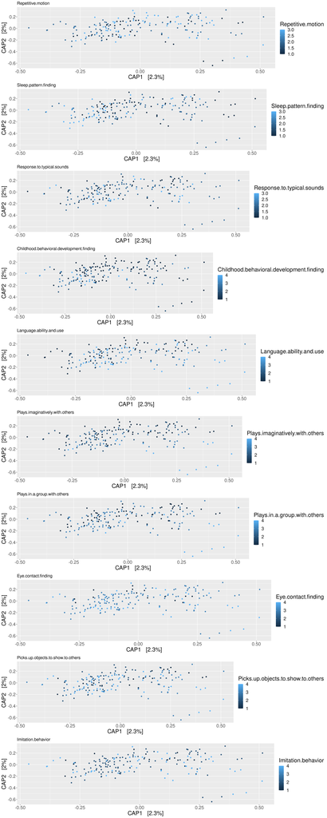

```r
#we keep only the cateory selected above as relevant
tmp_metadata <- map[,c(num_cat,fac_cat)]

#scores for social, learning, and anxiety
social <- c("Language.ability.and.use", "Conversation.ability", "Plays.imaginatively.when.alone", "Plays.imaginatively.with.others", "Plays.in.a.group.with.others", "Eye.contact.finding", "Picks.up.objects.to.show.to.others", "Imitation.behavior")

learning <- c("Understands.speech", "Childhood.behavioral.development.finding")

anxiety <- c("Repetitive.motion", "Sleep.pattern.finding", "Response.to.typical.sounds", "Self.injurious.behavior.finding", "Recent.anxiety..caretaker.reported.")

#only ASD
tmp_metadata<-tmp_metadata[tmp_metadata$phenotype == "A",]
ps_deseq_ASD <-subset_samples(ps_deseq, phenotype == "A")

#MARa variables
cols_keep <- c(anxiety[-which(anxiety %in% "Recent.anxiety..caretaker.reported.")], learning, social)
take_out<-behavior[-which(behavior %in% MARA$Variable)]
cols_keep<-cols_keep[-which(cols_keep %in% take_out)]
metadata <- tmp_metadata[ , cols_keep]

metadata <- metadata[complete.cases(metadata), ]

ps_deseq_pcoa <- ps_deseq_ASD
sample_data(ps_deseq_pcoa) <- metadata
f <- as.formula(paste0("~", paste0(colnames(metadata), collapse = "+")))

#ordination formula .
ord_pcoa <- ordinate(
  physeq = ps_deseq_pcoa,
  method = "CAP",
  distance = "bray",
  formula = f)

title_prep <- colnames(metadata)
to_plot=list()
for (i in 1:length(title_prep)){
  to_plot[[i]] <- plot_ordination(
  physeq = ps_deseq_pcoa,
  ordination = ord_pcoa,
  color = title_prep[i],
  axes = c(1,2),
  title=title_prep[i]
) +
  geom_point( size = 0.5) +
  theme(text = element_text(size =20), plot.title = element_text(size=15))
}

lay <- rbind(c(1),
             c(2),
             c(3),
             c(4),
             c(5),
             c(6),
             c(7),
             c(8),
             c(9),
             c(10))


#pdf(paste0(output_data,"confounding_factors.pdf",width=16,height=40))
grid.arrange(grobs = as.list(to_plot), layout_matrix = lay)
```

## Find associated taxa for each significant behavioral trait

```r
permanova_res<-read.csv(file ="../results/MARA_var_perma.csv", row.names = 1)
perma_var<-permanova_res$Variable
ps_no_norm_filt <- readRDS(paste0(output_data, "Filtered/ps_no_norm_friedfilt.rds"))

ps_no_norm_filt@sam_data$High_Anxiety<-gsub("1", "FALSE" ,ps_no_norm_filt@sam_data$Recent.anxiety..caretaker.reported.)
ps_no_norm_filt@sam_data$High_Anxiety<-gsub("2", "FALSE", ps_no_norm_filt@sam_data$High_Anxiety)
ps_no_norm_filt@sam_data$High_Anxiety<-gsub("3", "TRUE", ps_no_norm_filt@sam_data$High_Anxiety)
ps_no_norm_filt@sam_data$High_Anxiety <- as.factor(ps_no_norm_filt@sam_data$High_Anxiety)
#perma_var <- c(perma_var, "High_Anxiety")
ps_ASD<-subset_samples(ps_no_norm_filt, phenotype == "A")

taxa_associated_w_variables <- list()
for(var in perma_var[1:length(perma_var)]){
  print(var)
  tmp <- run_metagenom_seq(ps_ASD, variable = var, 30, .05, time = T)
  taxa_associated_w_variables[[var]] <- data.frame(rownames(tmp[[2]]), tmp[[2]]$adjPvalues, rep(var, nrow(tmp[[2]])))
}
```

```
## [1] "Childhood.behavioral.development.finding"
## [1] "Plays.imaginatively.with.others"
## [1] "Language.ability.and.use"
## [1] "Plays.in.a.group.with.others"
## [1] "Sleep.pattern.finding"
## [1] "Eye.contact.finding"
## [1] "Repetitive.motion"
## [1] "Response.to.typical.sounds"
```

```
## [1] "Picks.up.objects.to.show.to.others"
## [1] "Imitation.behavior"
```

```r
keep <- as.numeric(sapply(taxa_associated_w_variables, nrow)) > 0
taxa_associated_w_variables_keep <- do.call(rbind, taxa_associated_w_variables[keep])
if (!is.null(taxa_associated_w_variables_keep)){
colnames(taxa_associated_w_variables_keep) <- c("ASV", "adjPvalue", "variable")
}
write.csv(taxa_associated_w_variables_keep, paste0(output_data, "taxa_associated_w_behavioral_variables.csv"))
taxa_associated_w_variables_keep
```

```r
sig_res <- read.table(paste0(output_data, "significant_taxa_timeseries.tsv"), row.names = 1, sep = "\t", header = T)

sig_res[which(rownames(sig_res) %in% taxa_associated_w_variables_keep$ASV),]
```

```
##  [1] enrichment method     Domain     Phylum     Class      Order
##  [7] Family     Genus      Species    Strain
## <0 rows> (or 0-length row.names)
```

```r
high_anx_metagenomeseq<-sig_res[which(rownames(sig_res) %in% taxa_associated_w_variables_keep$ASV),]
high_anx_metagenomeseq
```

```
##  [1] enrichment method     Domain     Phylum     Class      Order
##  [7] Family     Genus      Species    Strain
## <0 rows> (or 0-length row.names)
```

```r
#write.csv(high_anx_metagenomeseq, "../High_anx_mtg_in_common_w_117.csv")

#whole datset
#sig_res[which(rownames(sig_res) %in% taxa_associated_w_high_anx_keep$ASV),]
```